# Explore and Summarize Data - Final Project

# Multivariate Analysis

### Talk about some of the relationships you observed in this part of the investigation. Were there features that strengthened each other in terms of looking at your feature(s) of interest?

For example, we can see that “residual.sugar” and “density” is positive correlated. And if we coluored the points by “alcohol.category”, we can see clear clusters. Generally, a wine with low density and high residual.sugar tend to contain more alcohol.

### Were there any interesting or surprising interactions between features?

Yes, I thought that 11 input variables are totally uncorrelated to each other. but after I quantified their correlation and use scatterplot to visualize it. I observed clear clusters pn the plot.

### OPTIONAL: Did you create any models with your dataset? Discuss the strengths and limitations of your model.

I used random forest to classificate the quality. I achieved about 72% accuracy rate as In-Sample performance. The strength of this model is that it’s very flexible and usually doesn’t have too much overfitting. The limitations is that the training data set is highly unbalanced, this may become a problem in generalization.

# Final Plots and Summary

### Plot One

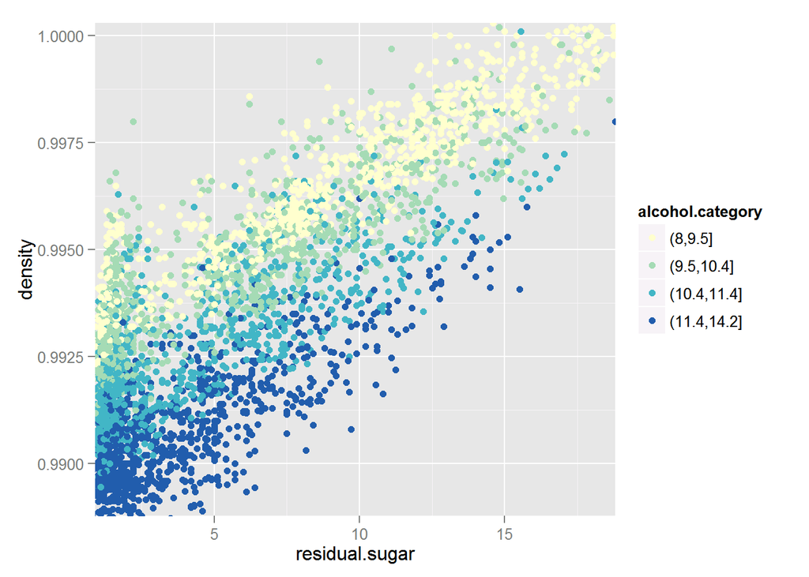

### Description One

I used “alcohol” to create a categorical variable “alcohol.category”. And I use scatterplot to observe strongly correlated variables and points were coloured by “alcohol.category”. We can see pretty clear but not 100% perfect hyperplanes to separate points. we can see that “residual.sugar” and “density” is positive correlated. And if we coluored the points by “alcohol.category”, we can see clear clusters. Generally, a wine with low density and high residual.sugar tend to contain more alcohol. And a wine with high density and low residual.sugar tend to contain less alcohol.

### Plot Two

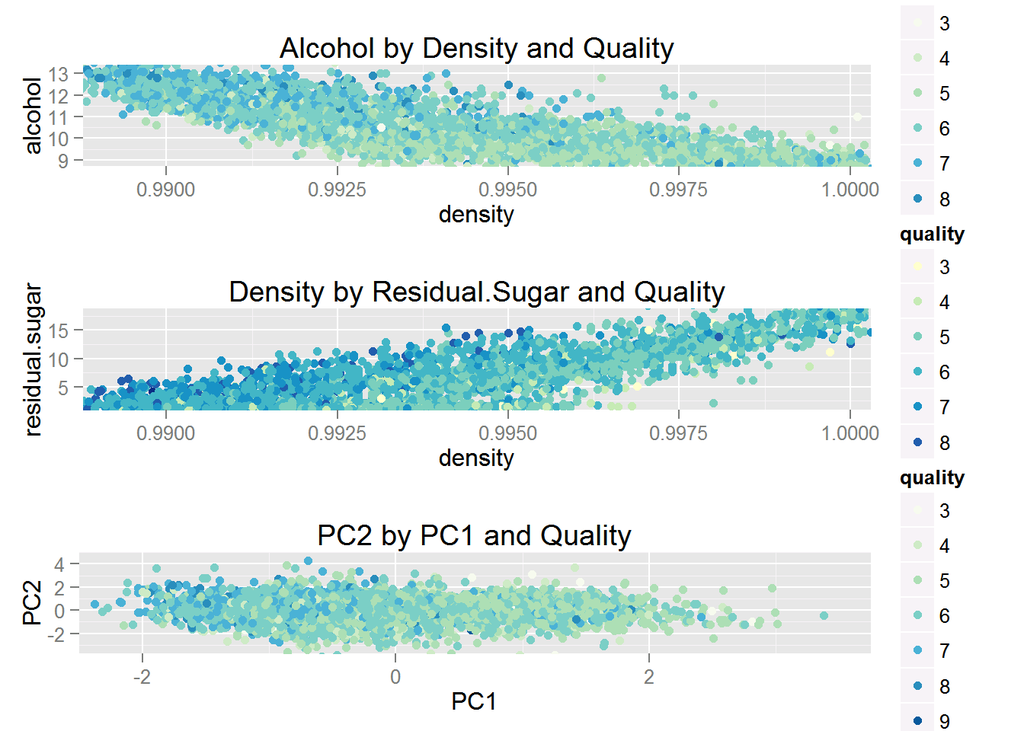

### Plot Three

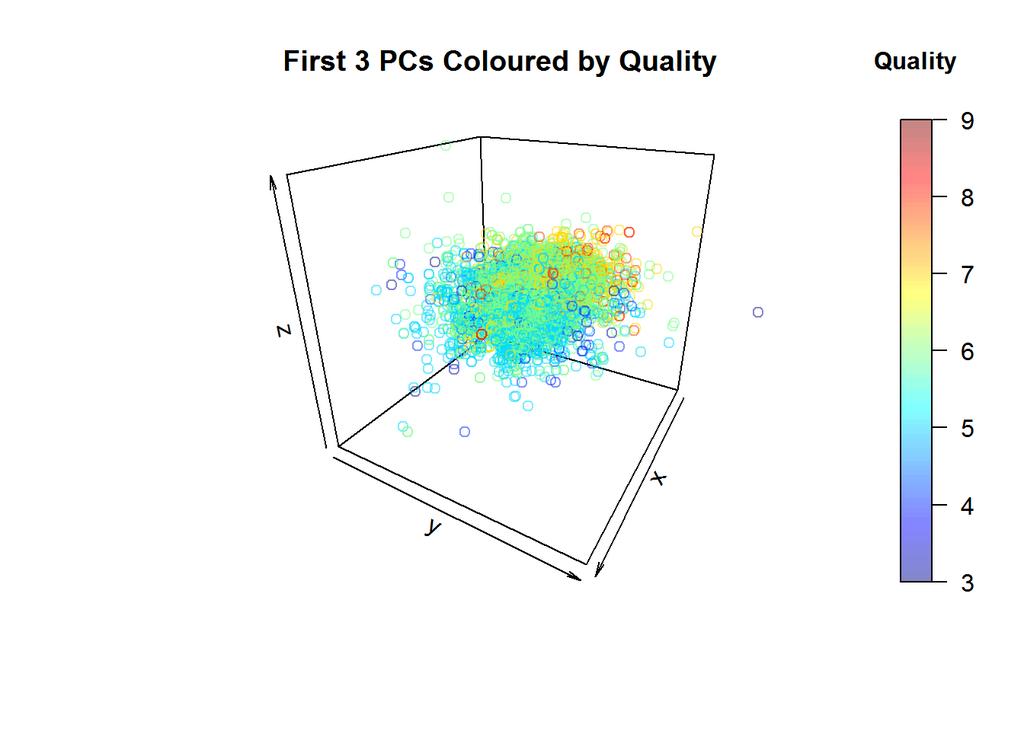

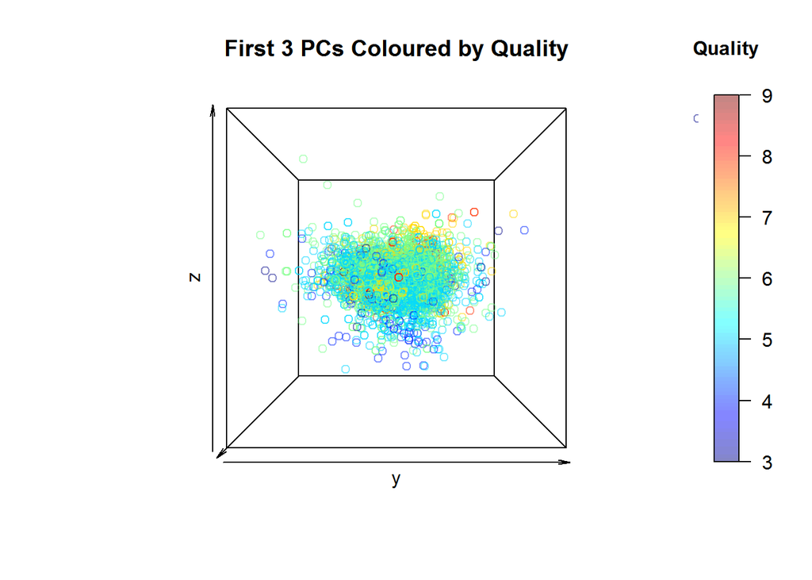

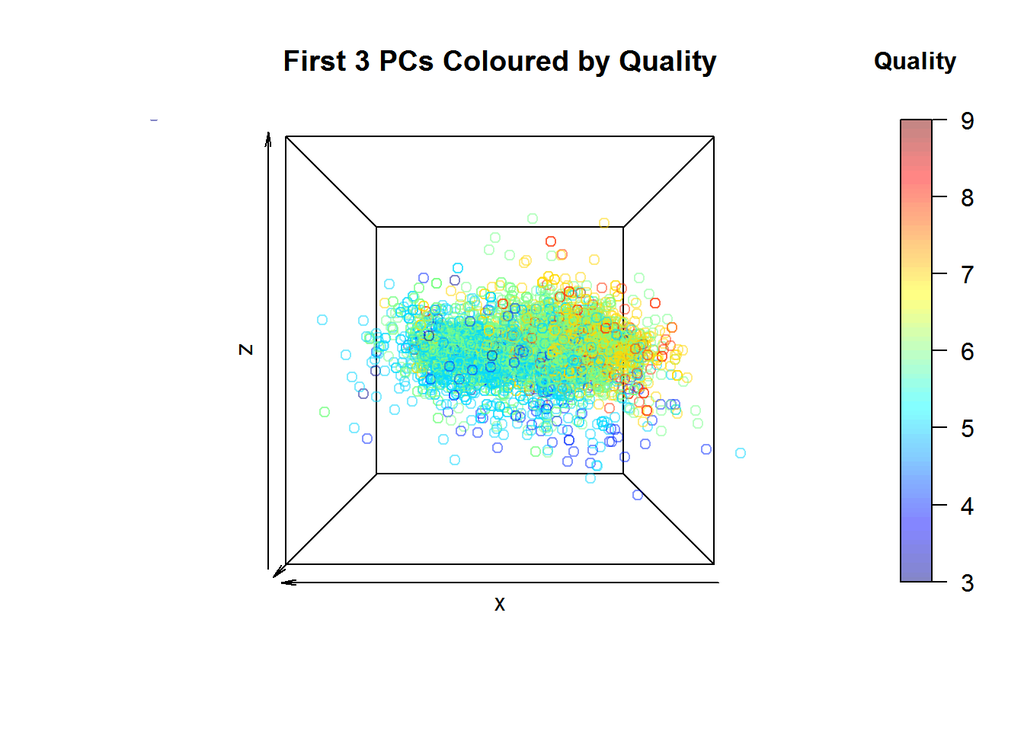

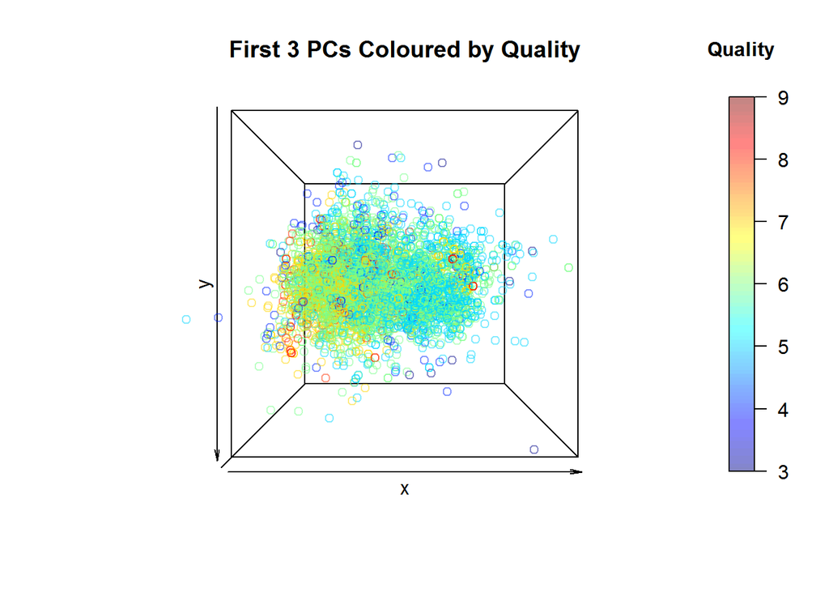

### Description Three

Well, this plot is not as beautiful as any plots before. The XYZ-axis are first 3 principal components which explain 55% percent of variance. And it’s better than the last plot, the points are clustered more clear. if we check the loadings matrix of PCA, we can get some sense about how the data being distributed in that 3-Dimensional Space. And we can see though there may exist some curve surfaces that can separate those points well, the variables’ information may still support our classification in an very complex and non-linear way. we should use more flexible model like svm or random forest to model our data, though we can also try multinomial logistic regression first.

# Reflection

This dataset has 4898 observations with 11 input variables and 1 output variable. Actually, I have zero domain knowledge about wine, therefore I heavily rely on data analysis to get some sense. I only found one input variable are slightly correlated with output variable. Though I found some input variables are correlated with each other which may bring us to other interesting topic, but it could not help us to build better model. Plus, I also conduct principal component analysis, trying to combine all the input variables together. As result, this dimension reduction method help me find the direction which contain most variance. From the “First 3 Principal Components Coloured by Quality” plot, we could find a few hyperplanes that roughly separate data points. Since I did not find strong linear patterns in exploratory data analysis, I used random forest to build a classification model. I achieved about 72% accuracy rate as In-Sample performance. However, Since modeling is not our main topic, I didn’t separate the data to training data set and testing data set. Therefore, I didn’t do pre-processing for the input variables to avoid overfitting and I didn’t do anything to address the unbalanced data problem. The strength of this model is that it’s very flexible and usually doesn’t have too much overfitting. The limitations is that the training data set is highly unbalanced, this may become a problem in generalization.